# Shrimp modeling

## Data:

Data we have at month-year-fishing area resolution:

- Average length and sample size for each age class (1-3) from April to October, i.e., up to 21 observations of each year class in a given area, but some combinations are missing. This is from sampling the catch.
- SD for each age class from 2014-2018 (actually have individual data for each shrimp measured in these years)
- Total catch in lbs
- Count per pound
- Percent age composition of the catch by number
- All of this for 1989-2018, though a lot of pubs seems to have 1980-present

Here is a (different) plot of the mean lengths at age by area and year class.

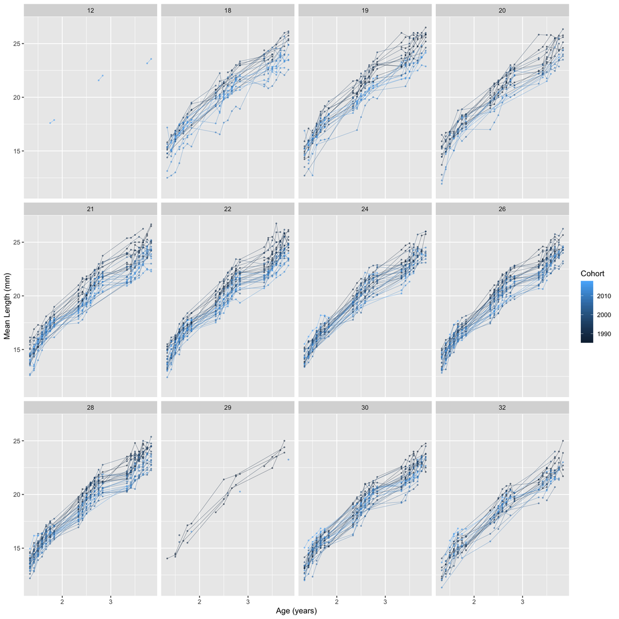

Here is a map of the state areas:

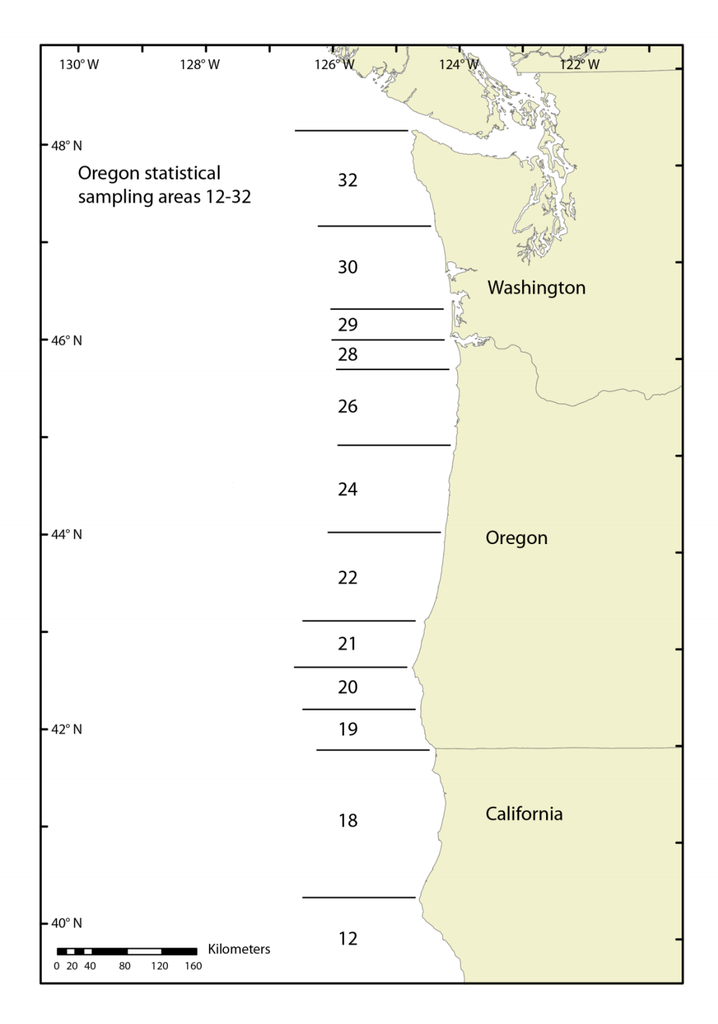

## Length model:

$L_{a,y,m}$ is length of age $a$ shrimp in month $m$ of year $y$. Then

$$\begin{aligned}
L_{1,y,1} &= \alpha_0 + \epsilon_{1,y,1} \\
L_{a,y,m} &= \alpha_1 + \beta_1 L_{a,y,m-1} + \epsilon_{a,y,m} \\
L_{a,y,1} &= \alpha_2 + \beta_2 L_{a-1, y-1, m_{\max}} + \epsilon_{a,y,1}
\end{aligned}$$

$\alpha_0$ is average size of age 1 shrimp in April, $\alpha_1$ is the within fishing season monthly growth increment, $\alpha_2$ is the across fishing season growth increment, and $\beta_1$ and $\beta_2$ are the density-dependent terms within and across fishing seasons, respectively. Right now I assume $\alpha_1 = \alpha_2$ and $\beta_1 = \beta_2$ though I don’t think that is correct as there is not much wintertime growth. All of these can be functions of environmental variables. There is also an existing theory that growth is density-dependent, so they grow less when there are more shrimp around. The process variability $\epsilon$ follows a normal distribution, and I estimate a separate $\sigma_\text{init size}$ and $\sigma_\text{growth}$.

## Observation model:

$$\bar{L}_{a,y,m,area} \sim N\left(L_{a,y,m} + \gamma_{area}, \frac{\sigma_\text{obs}}{\sqrt{n_{a,y,m,area}}} \right)$$

where $\bar{L}_{a,y,m,area}$ is the empirical mean length for age $a$ in month $m$ of year $y$ sampled in area $area$, $\sigma_\text{obs}$ is the observation standard deviation, $n_{a,y,m,area}$ is the number of age $a$ shrimp that were sampled from the catch in month $m$ of year $y$ in area $area$, and $\gamma_{area} \sim N(0, \sigma_\text{area})$. The $\gamma$ offset allows different areas to have consistently smaller or larger shrimp.

## Fitting:

The model is fit in stan as a multivariate autoregressive state-space model. Each year class is a different “state,” but the underlying parameters for each state are the same (for now). Each area represents a different observation process of the same state.

# Results:

First, here is a table of the estimated parameters. Some of the effective sample sizes are kind of low and I should probaby run this longer.

|  | mean | se_mean | sd | 2.5% | 25% | 50% | 75% | 97.5% | n_eff | Rhat |
| --- | --- | --- | --- | --- | --- | --- | --- | --- | --- | --- |
| *α*<sub>0</sub> | -5.5970924 | 0.0156525 | 0.2242362 | -6.0244432 | -5.7500073 | -5.6043549 | -5.4414946 | -5.1510167 | 205.2305 | 1.0268758 |
| *σ*<sub>init size</sub> | 0.6317403 | 0.0015151 | 0.0947395 | 0.4751073 | 0.5638242 | 0.6219299 | 0.6902798 | 0.8427652 | 3910.2819 | 0.9997150 |
| *σ*<sub>area</sub> | 0.6633556 | 0.0038501 | 0.1630368 | 0.4315529 | 0.5453173 | 0.6349535 | 0.7440498 | 1.0640291 | 1793.2079 | 0.9999723 |
| *α*<sub>1</sub> | 0.4984360 | 0.0007284 | 0.0166600 | 0.4660016 | 0.4871278 | 0.4987041 | 0.5095675 | 0.5301932 | 523.0669 | 1.0058931 |
| *β*<sub>1</sub> | 0.9594322 | 0.0001274 | 0.0052302 | 0.9490951 | 0.9559111 | 0.9596002 | 0.9629428 | 0.9697195 | 1685.5239 | 1.0002110 |
| *σ*<sub>growth</sub> | 0.3368795 | 0.0003935 | 0.0150943 | 0.3079236 | 0.3263908 | 0.3367658 | 0.3469990 | 0.3677340 | 1471.0489 | 1.0001194 |
| *σ*<sub>obs</sub> | 5.5635890 | 0.0008737 | 0.0657969 | 5.4334080 | 5.5203553 | 5.5644861 | 5.6077428 | 5.6954588 | 5671.9088 | 0.9994317 |

Second, here is a plot of residuals versus fitted values (using the median from the posterior as the fitted value) with a smoother. We see that the residuals look alright.

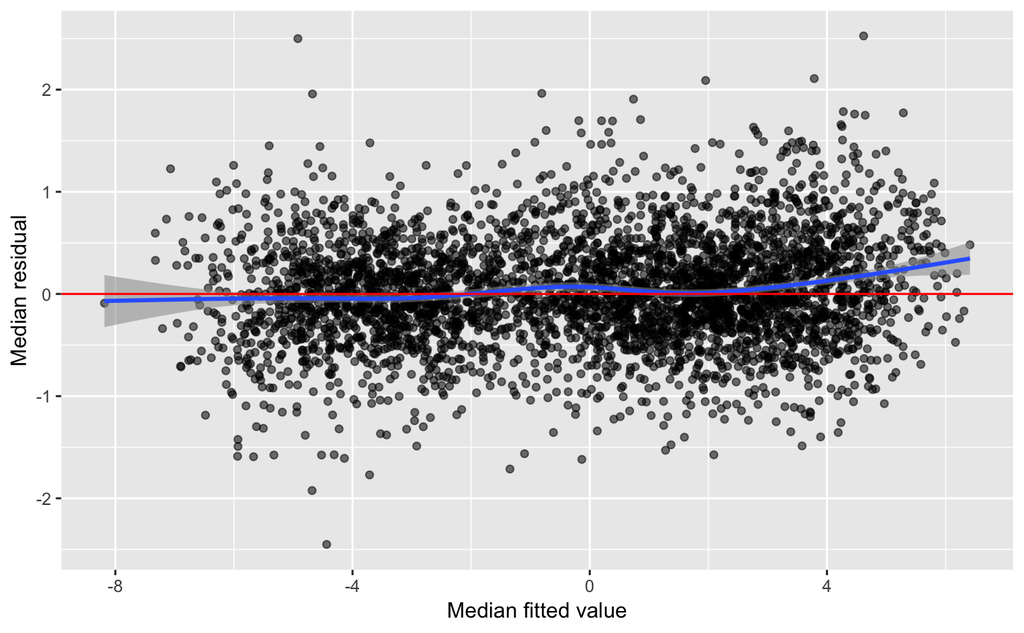

Here is a plot of residuals split up by area. I fixed the problem!

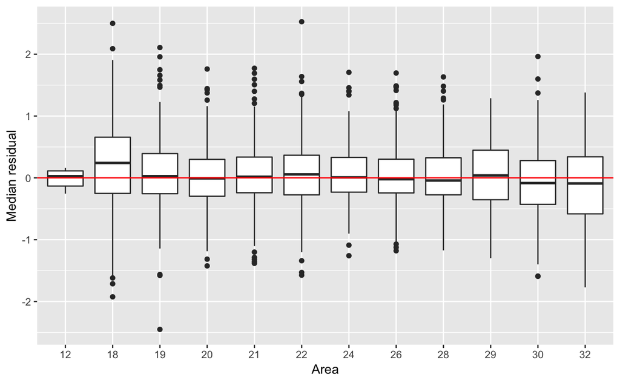

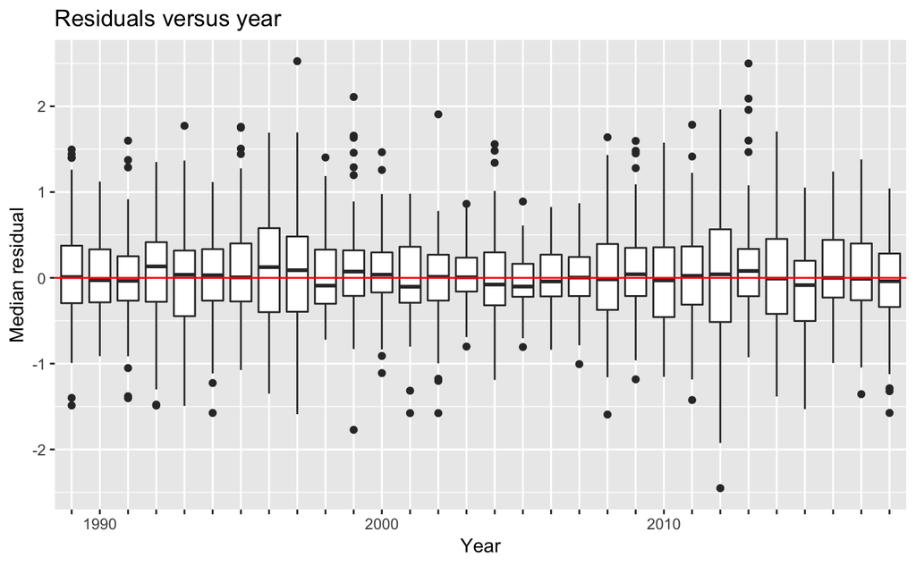

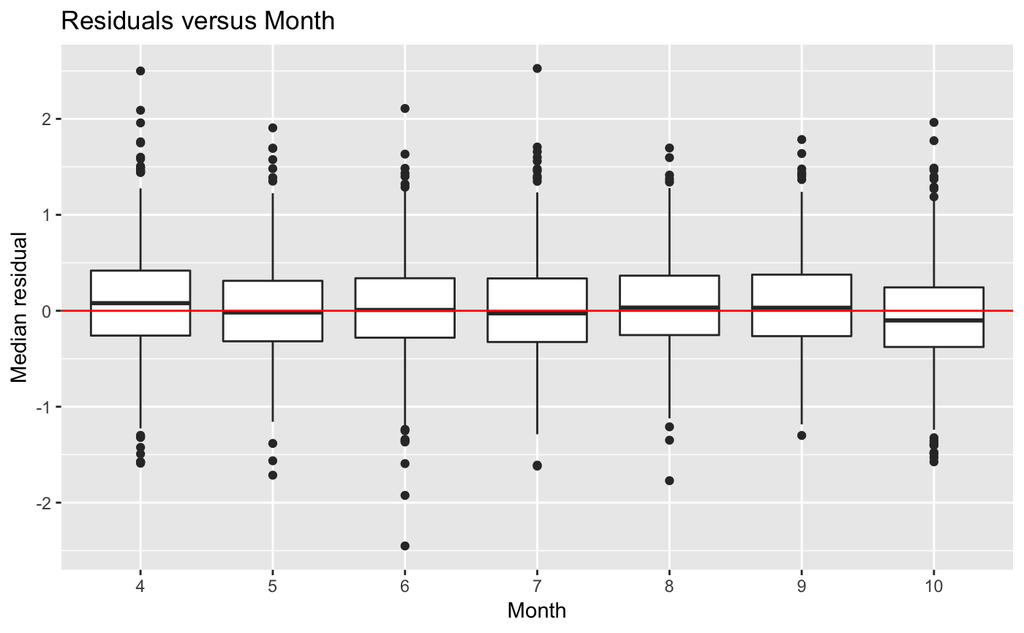

I also thought it would be useful to look at the process errors. We can see that the process model is not working great, especially for the first over-winter growth increment.

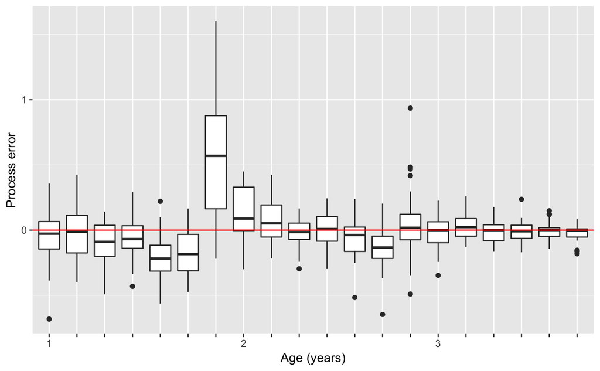

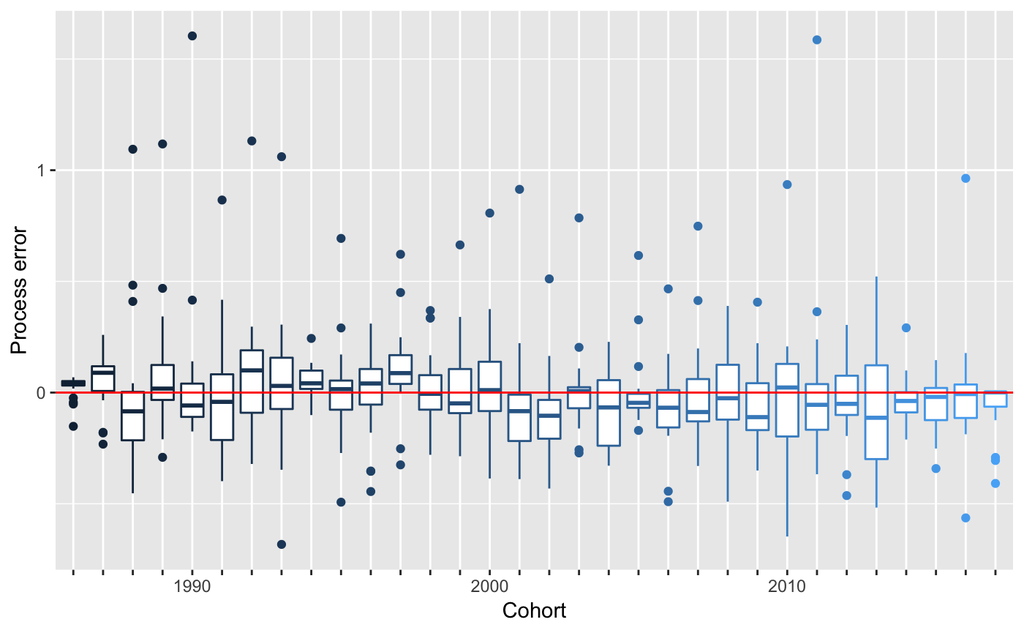

## Next steps:

I think I should try to fix the wintertime growth problem.